# Clase 5 Modelos

Barbara Peña

20-09-2020

install.packages(“rticles”) tinytex::install_tinytex

# ¿Qué es un modelo?

- Un modelo es una versión simplificada de la realidad que nos permite hacer inferencias o prediccións sobre una población
- Un modelo es un resumen adecuado de la realidad
- Un modelo es una simplificación or aproximación a la realidad y por ende no reflejará toda la realidad (Burnham y Anderson)
- Todos los modelos estan equivocados, algunos son útiles (George Box)

# Abrir base de datos

```r
data("CO2")
View(CO2)
```

## Exploremos la data

¿Qué variable explica mejor la variación de uptake en esta base de datos?

### La especie?

Recordar que notch marca el intervalo de confianza del 95% de la mediana.

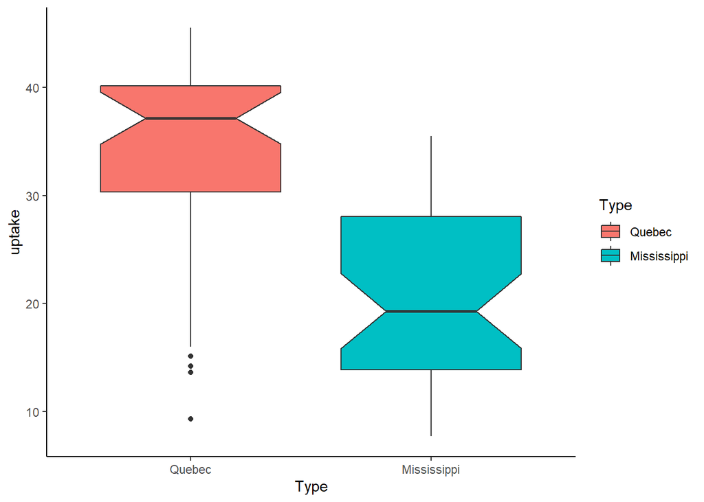

```r
ggplot(CO2, aes(x= Type, y= uptake)) + geom_boxplot(aes(fill=Type), notch = T) + theme_classic()
```

## El tratamiento ?

Recordar que notch marca el intervalo de confianza del 95% de la mediana.

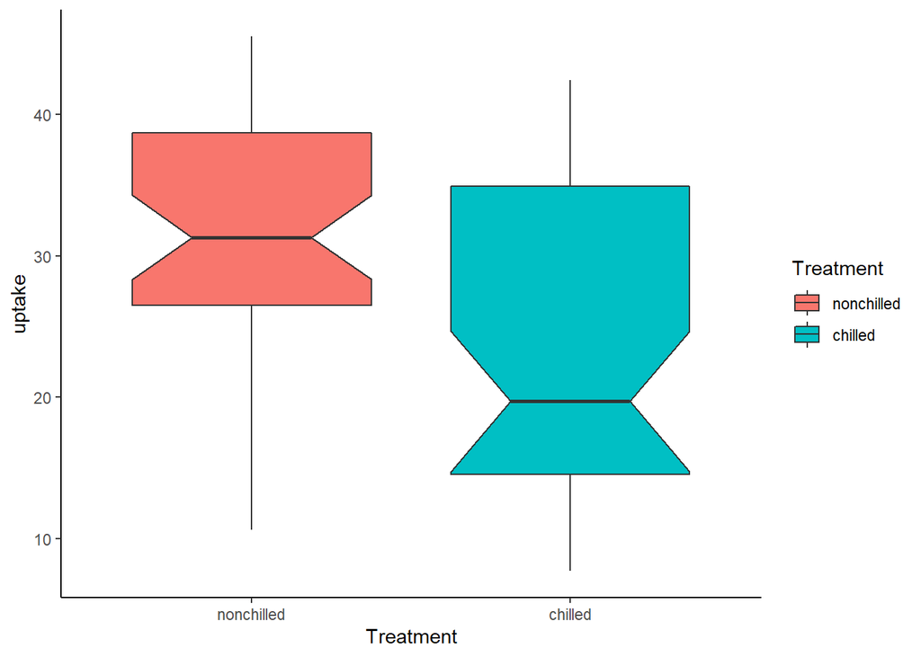

```r
ggplot(CO2, aes(x= Treatment, y= uptake)) + geom_boxplot(aes(fill= Treatment), notch = T) + theme_classic()
```

## La concentración?

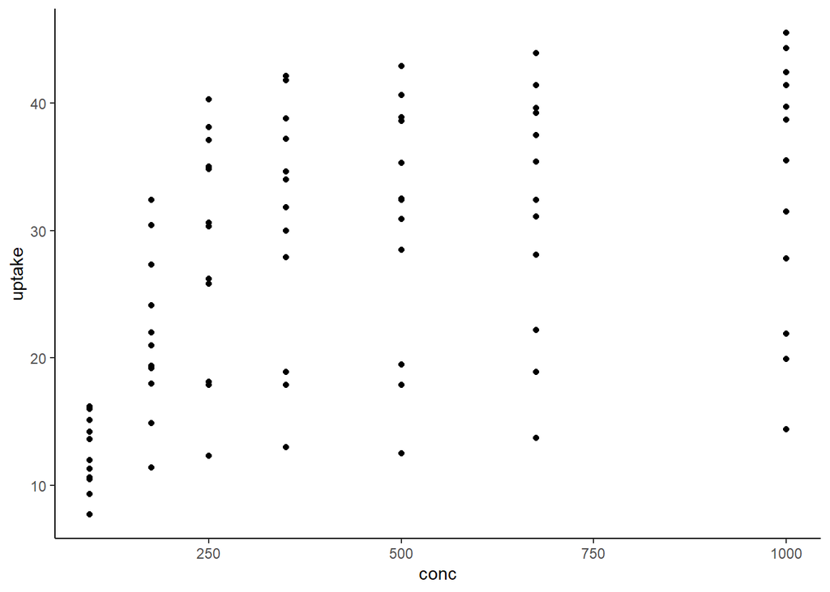

```r
ggplot(CO2, aes(x= conc, y= uptake)) + geom_point() + theme_classic()
```

#¿Como determinamos un buen modelo?. Fórmula de un modelo

Alguna_funcion(Y~ X1 + X2 + …+ Xn, data= data.frame)

- Y= variale repsuesta (Captacion CO2)
- ~ = Explicado por
- Xn= Variable explicativa n (Subespeice, tratamiento,etc)

data.frame= Base de datos CO2 alguna_funcion: El modelo a testear (muestra una simplificación de la realidad)

## **Algunos modelos**

- prueba t
- ANOVA
- modelo lineal simple
- modelo lineal generalizado
- modelo aditivo
- modelo no lineal
- modelos lineales mixtos
- bossted regression trees

## Cual usamos ahora ?

Modelo lineal, capatacion de CO2 explicado por ecotipo (variable categorica)

```r
Fit1 <- lm(formula = uptake ~ Type, data = CO2)
```

Esto es equivalente a un ANOVA, si estamos ocupando un modelo lineal simple con una variable categorica

### Usar brrom para sacarle mas a tu modelo (glance)

para ver los daos generales del modelo

```r
library(broom)
```

### glance

Para el modelo general, glance, para ver datos generales del modelo

```r
Est1<- glance(Fit1)
Est1
```

```
## # A tibble: 1 x 12
##   r.squared adj.r.squared sigma statistic p.value    df logLik   AIC   BIC
##       <dbl>         <dbl> <dbl>     <dbl>   <dbl> <dbl>  <dbl> <dbl> <dbl>
## 1     0.347         0.339  8.79      43.5 3.83e-9     1  -301.  608.  615.
## # ... with 3 more variables: deviance <dbl>, df.residual <int>, nobs <int>
```

```r
Est1 %>% select(r.squared:sigma, df:AIC)
```

```
## # A tibble: 1 x 6
##   r.squared adj.r.squared sigma    df logLik   AIC
##       <dbl>         <dbl> <dbl> <dbl>  <dbl> <dbl>
## 1     0.347         0.339  8.79     1  -301.  608.
```

```r
Est1 %>%  select(r.squared, adj.r.squared, p.value, nobs )
```

```
## # A tibble: 1 x 4
##   r.squared adj.r.squared       p.value  nobs
##       <dbl>         <dbl>         <dbl> <int>
## 1     0.347         0.339 0.00000000383    84
```

### tidy

Para ver los parametros de otra manera

```r
Est2 <-tidy(Fit1)
Est2
```

```
## # A tibble: 2 x 5
##   term            estimate std.error statistic  p.value
##   <chr>              <dbl>     <dbl>     <dbl>    <dbl>
## 1 (Intercept)         33.5      1.36     24.7  9.23e-40
## 2 TypeMississippi    -12.7      1.92     -6.60 3.83e- 9
```

### Augment

Para predicciones y residuales del modelo

```r
augment(Fit1)
```

```
## # A tibble: 84 x 8
##    uptake Type   .fitted .resid .std.resid   .hat .sigma  .cooksd
##     <dbl> <fct>    <dbl>  <dbl>      <dbl>  <dbl>  <dbl>    <dbl>
##  1   16   Quebec    33.5 -17.5      -2.02  0.0238   8.63 0.0497
##  2   30.4 Quebec    33.5  -3.14     -0.362 0.0238   8.84 0.00160
##  3   34.8 Quebec    33.5   1.26      0.145 0.0238   8.85 0.000255
##  4   37.2 Quebec    33.5   3.66      0.421 0.0238   8.84 0.00216
##  5   35.3 Quebec    33.5   1.76      0.202 0.0238   8.85 0.000499
##  6   39.2 Quebec    33.5   5.66      0.651 0.0238   8.83 0.00517
##  7   39.7 Quebec    33.5   6.16      0.709 0.0238   8.82 0.00612
##  8   13.6 Quebec    33.5 -19.9      -2.30  0.0238   8.56 0.0642
##  9   27.3 Quebec    33.5  -6.24     -0.719 0.0238   8.82 0.00630
## 10   37.1 Quebec    33.5   3.56      0.409 0.0238   8.84 0.00204
## # ... with 74 more rows
```

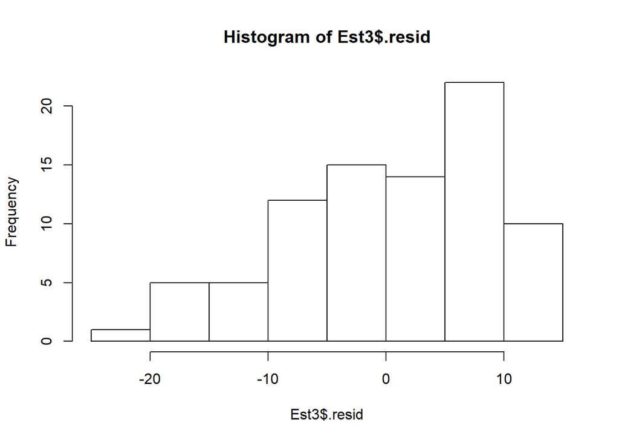

```r
Est3 <- augment(Fit1)
hist(Est3$.resid)
```

# Seleccion de modelos

Uno por lo general trabaja con varios modelos - En general uno lo hace en base a AIC -K= nummero de parametros, en caso de Fit 1, intercepto y ecotipo -Ln (L) ajust, mas positivo mejor, mas negatico es malo, loglik - AIC=2K-2ln(L)

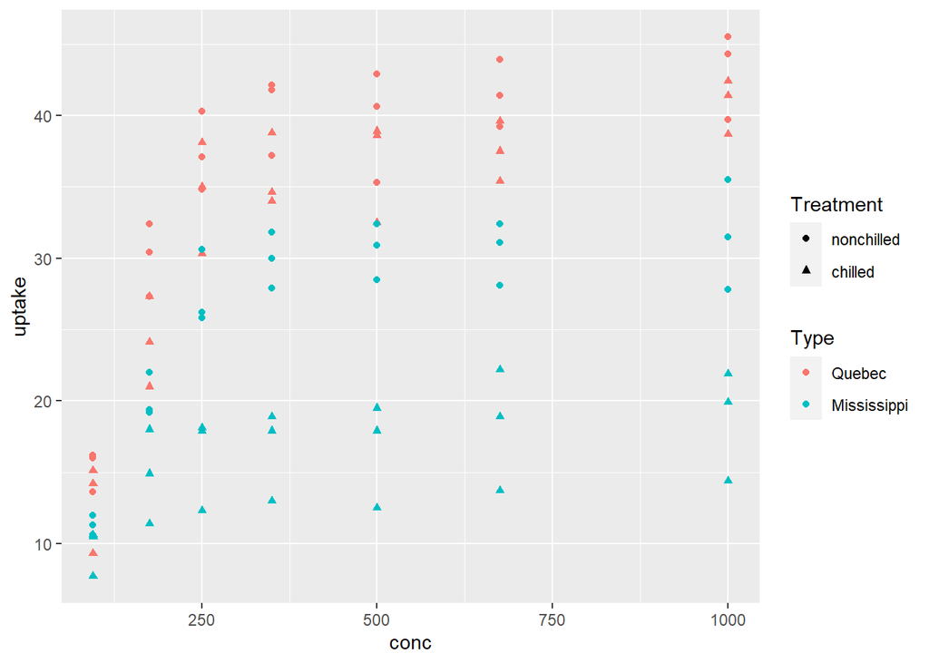

```r
ggplot(CO2, aes(x=conc, y=uptake, color=Type)) + geom_point(aes(shape= Treatment))
```

### Comparacion de modelos

```r
Fit1 <- lm(formula = uptake ~ Type, data = CO2)
```

```r
Fit2 <- lm(uptake ~ Treatment, data = CO2)
Fit3 <- lm(uptake ~ conc, data = CO2)
Fit4 <- lm(uptake ~ Type + Treatment + conc, data = CO2)
Fit5 <- lm(uptake ~ Type + conc + I(log(conc)), data = CO2)
Fit6 <- lm(uptake ~ Type:Treatment + conc + I(log(conc)), data = CO2)
```

### Seleccion de modelos con broom

```r
Modelo1 <- glance(Fit1) %>% dplyr::select(r.squared, AIC) %>% mutate(Modelo = "Fit1")
Modelo2 <- glance(Fit2) %>% dplyr::select(r.squared, AIC) %>% mutate(Modelo = "Fit2")
Modelo3 <- glance(Fit3) %>% dplyr::select(r.squared, AIC) %>% mutate(Modelo = "Fit3")
Modelo4 <- glance(Fit4) %>% dplyr::select(r.squared, AIC) %>% mutate(Modelo = "Fit4")
Modelo5 <- glance(Fit5) %>% dplyr::select(r.squared, AIC) %>% mutate(Modelo = "Fit5")
Modelo6 <- glance(Fit6) %>% dplyr::select(r.squared, AIC) %>% mutate(Modelo = "Fit6")
```

### Ranking de modelos

El mejor es el con menor AIC

```r
Modelos <- bind_rows(Modelo1, Modelo2, Modelo3, Modelo4,
                     Modelo5, Modelo6) %>% arrange(AIC) %>% mutate(DeltaAIC = AIC -
                                                            min(AIC))
Modelos
```

```
## # A tibble: 6 x 4
##   r.squared   AIC Modelo DeltaAIC
##       <dbl> <dbl> <chr>     <dbl>
## 1     0.874  477. Fit6        0
## 2     0.749  531. Fit5       53.9
## 3     0.684  551. Fit4       73.2
## 4     0.347  608. Fit1      130.
## 5     0.235  621. Fit3      143.
## 6     0.102  634. Fit2      157.
```

Cómo saber que variable predictora usar? y como saber como interacción?

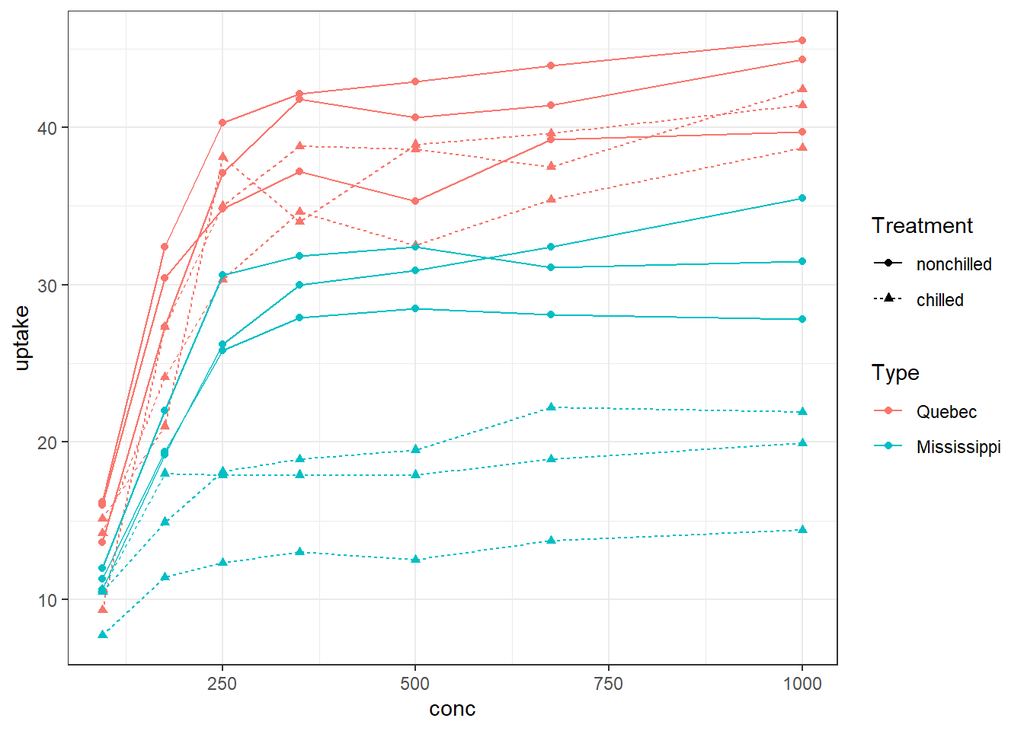

```r
ggplot(CO2, aes(x=conc, y=uptake, group=Plant)) +
  geom_point(aes(color= Type, shape=Treatment)) +
  geom_line(aes(color=Type, lty=Treatment))+ theme_bw()###lty=tipo de linea
```

Al mirar el grafico, vemos que la especie hace una diferencia, y que el tratamiento tambien, pero dicho efecto depende de la especie.

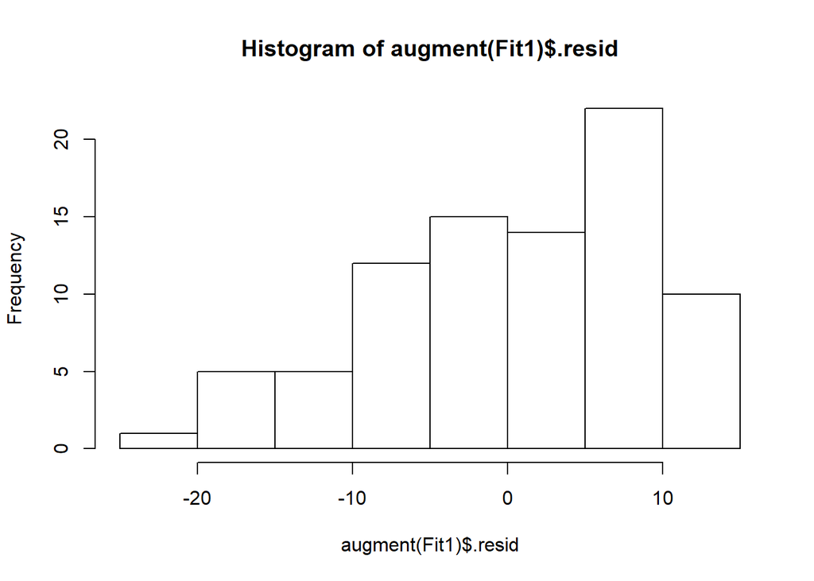

```r
hist(augment(Fit1)$.resid)
```

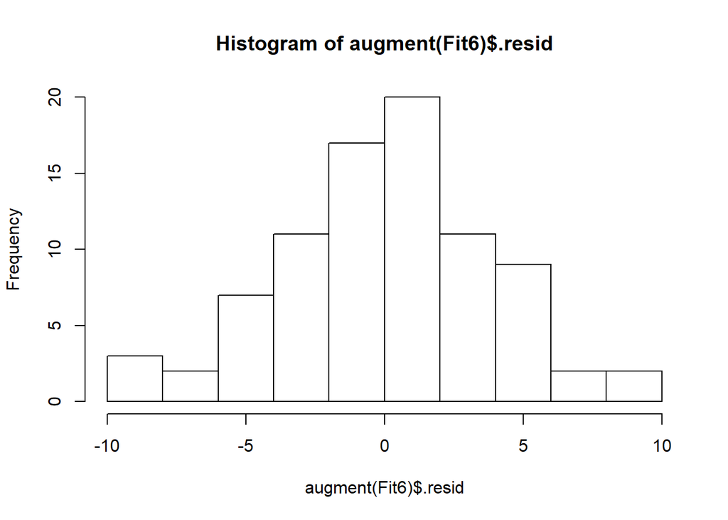

```r
hist(augment(Fit6)$.resid) ## distribucion mas normal
```